# MPDW TUGAS3

Berliana Destari Hermansyah

2025-09-04

```r
install.packages("https://cran.r-project.org/src/contrib/Archive/orcutt/orcutt_2.1.tar.gz",
                 repos = NULL, type = "source")
#install.packages("orcutt")
#install.packages("HoRM")
```

```r
library(dplyr)
library(TTR)
library(forecast)
library(lmtest) #digunakan untuk uji formal pendeteksian autokorelasi
library(orcutt) #untuk membuat model regresi Cochrane-Orcutt
library(HoRM) #untuk membuat model regresi Hildreth-Lu
```

# Input Data

Data IPM Provinsi Kalimantan Timur dari tahun 2004-2024

```r
tahun <- c(2004,2005, 2006, 2007, 2008, 2009, 2010,2011,2012,2013,2014,2015,2016,2017,2018,2019,2020,2021, 2022, 2023, 2024)
ipm <- c(72.20, 72.94, 73.26, 73.77, 74.52, 75.11, 71.31, 72.02, 72.62, 73.21, 73.82, 74.17, 74.59, 75.12, 75.83, 76.61, 76.24, 76.88, 77.44, 78.20, 78.83 )
dtKaltim <- cbind(tahun,ipm)
dtKaltim <- as.data.frame(dtKaltim)
dtKaltim
```

```
##    tahun   ipm
## 1   2004 72.20
## 2   2005 72.94
## 3   2006 73.26
## 4   2007 73.77
## 5   2008 74.52
## 6   2009 75.11
## 7   2010 71.31
## 8   2011 72.02
## 9   2012 72.62
## 10  2013 73.21
## 11  2014 73.82
## 12  2015 74.17
## 13  2016 74.59
## 14  2017 75.12
## 15  2018 75.83
## 16  2019 76.61
## 17  2020 76.24
## 18  2021 76.88
## 19  2022 77.44
## 20  2023 78.20
## 21  2024 78.83
```

# Menguji Autokorelasi

```r
library(lmtest)
library(car)
dtKaltim <- data.frame(tahun, ipm)

# Model regresi sederhana (ipm ~ tahun)
model <- lm(ipm ~ tahun, data = dtKaltim)

# Uji autokorelasi Durbin-Watson
dwtest(model)
```

```
##
##  Durbin-Watson test
##
## data:  model
## DW = 0.75201, p-value = 0.0001705
## alternative hypothesis: true autocorrelation is greater than 0
```

```r
# Uji Ljung-Box (autokorelasi residual)
Box.test(resid(model), lag = 1, type = "Ljung-Box")
```

```
##
##  Box-Ljung test
##
## data:  resid(model)
## X-squared = 8.386, df = 1, p-value = 0.003781
```

Hasil pengujian autokorelasi terhadap model regresi IPM menunjukkan adanya masalah pada residual. *Nilai Durbin-Watson sebesar 0,75* yang jauh di bawah angka 2 mengindikasikan adanya */autokorelasi positif yang kuat.*/ Temuan ini diperkuat oleh nilai p-value sebesar 0,00017 yang signifikan pada taraf uji 5 persen, sehingga hipotesis nol tentang tidak adanya autokorelasi dapat ditolak. Uji konfirmasi dengan Box-Ljung test juga memberikan hasil konsisten, di mana nilai statistik uji sebesar 8,386 dengan p-value 0,00378 kembali menegaskan adanya autokorelasi dalam residual.

# Eksplorasi Data

Sebelum melakukan regresi, akan diperlihatkan *plot time-series* dari IPM Provinsi Kalimantan Timur Periode 2004-2024

```r
#Membentuk objek time series
data.ts<-ts(dtKaltim$ipm)
data.ts
```

```
## Time Series:
## Start = 1
## End = 21
## Frequency = 1
##  [1] 72.20 72.94 73.26 73.77 74.52 75.11 71.31 72.02 72.62 73.21 73.82 74.17
## [13] 74.59 75.12 75.83 76.61 76.24 76.88 77.44 78.20 78.83
```

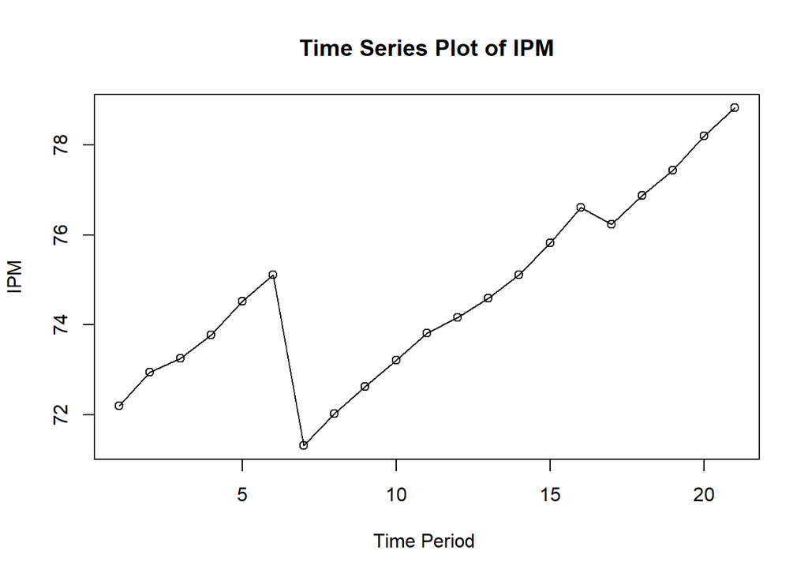

```r
#Membuat plot time series
ts.plot(data.ts, xlab="Time Period ", ylab="IPM", main= "Time Series Plot of IPM")
points(data.ts)
```

Hasil visualisasi menunjukkan bahwa data memiliki tren meningkat secara konsisten dari periode awal hingga akhir, meskipun sempat terjadi anomali penurunan tajam pada periode ke-6. Setelah titik tersebut, pola kembali stabil dengan kecenderungan naik hingga mencapai level tertinggi pada observasi terakhir. Hal ini menandakan adanya long-term upward trend pada data.

Jika dikaitkan dengan autokorelasi (ACF), pola yang relatif mulus setelah periode ke-6 mengindikasikan adanya keterkaitan kuat antar-observasi berurutan. Artinya, nilai pada suatu periode sangat dipengaruhi oleh nilai periode sebelumnya. Puncak penurunan pada periode ke-6 dapat dilihat sebagai gangguan yang bersifat sementara, bukan perubahan struktural, karena tren jangka panjang tetap berlanjut naik. *Secara keseluruhan, data ini merefleksikan karakteristik time series dengan tren positif dan autokorelasi signifikan.*

Selanjutnya akan dilakukan ramalan dan pemulusan dengan metode DMA dan DES karena terlihat pada plot di atas menunjukkan adanya *trend*.

# Pemulusan dengan DMA

```r
dt.sma <- SMA(data.ts, n=3)
dma <- SMA(dt.sma, n = 3)
At <- 2*dt.sma - dma
Bt <- 2/(3-1)*(dt.sma - dma)
dt.dma<- At+Bt
dt.ramal<- c(NA, dt.dma)

t = 1:5
f = c()

for (i in t) {
  f[i] = At[length(At)] + Bt[length(Bt)]*(i)
}
```

```r
dt.gab <- cbind(aktual = c(data.ts,rep(NA,5)),
                pemulusan1 = c(dt.sma,rep(NA,5)),
                pemulusan2 = c(dt.dma, rep(NA,5)),
                At = c(At, rep(NA,5)),
                Bt = c(Bt,rep(NA,5)),
                ramalan = c(dt.ramal, f[-1]))
dt.gab
```

```
##       aktual pemulusan1 pemulusan2       At         Bt  ramalan
##  [1,]  72.20         NA         NA       NA         NA       NA
##  [2,]  72.94         NA         NA       NA         NA       NA
##  [3,]  73.26   72.80000         NA       NA         NA       NA
##  [4,]  73.77   73.32333         NA       NA         NA       NA
##  [5,]  74.52   73.85000   74.90111 74.37556  0.5255556       NA
##  [6,]  75.11   74.46667   75.64000 75.05333  0.5866667 74.90111
##  [7,]  71.31   73.64667   72.96444 73.30556 -0.3411111 75.64000
##  [8,]  72.02   72.81333   71.15556 71.98444 -0.8288889 72.96444
##  [9,]  72.62   71.98333   70.32111 71.15222 -0.8311111 71.15556
## [10,]  73.21   72.61667   72.90778 72.76222  0.1455556 70.32111
## [11,]  73.82   73.21667   74.43889 73.82778  0.6111111 72.90778
## [12,]  74.17   73.73333   74.82222 74.27778  0.5444444 74.43889
## [13,]  74.59   74.19333   75.15111 74.67222  0.4788889 74.82222
## [14,]  75.12   74.62667   75.51111 75.06889  0.4422222 75.15111
## [15,]  75.83   75.18000   76.20667 75.69333  0.5133333 75.51111
## [16,]  76.61   75.85333   77.12000 76.48667  0.6333333 76.20667
## [17,]  76.24   76.22667   77.17333 76.70000  0.4733333 77.12000
## [18,]  76.88   76.57667   77.29222 76.93444  0.3577778 77.17333
## [19,]  77.44   76.85333   77.45556 77.15444  0.3011111 77.29222
## [20,]  78.20   77.50667   78.56222 78.03444  0.5277778 77.45556
## [21,]  78.83   78.15667   79.45889 78.80778  0.6511111 78.56222
## [22,]     NA         NA         NA       NA         NA 79.45889
## [23,]     NA         NA         NA       NA         NA 80.11000
## [24,]     NA         NA         NA       NA         NA 80.76111
## [25,]     NA         NA         NA       NA         NA 81.41222
## [26,]     NA         NA         NA       NA         NA 82.06333
```

[figure not shown]

```r
#Plot time series
ts.plot(dt.gab[,1], xlab="Time Period ", ylab="IPM",
        main= "DMA N=3 Data IPM", ylim=c(62,75))
points(dt.gab[,1])
points(dt.gab[,3])
points(dt.gab[,6])
lines(dt.gab[,3],col="green",lwd=2)
lines(dt.gab[,6],col="red",lwd=2)
legend("topleft",c("data aktual","data pemulusan","data peramalan"),
       lty=8, col=c("black","green","red"), cex=0.8)
```

Pada bagian awal periode, terlihat bahwa garis ramalan cukup jauh menyimpang dari data aktual. Hal ini wajar karena metode moving average membutuhkan beberapa data awal untuk membentuk rata-rata sehingga prediksi menjadi agak tertinggal. Memasuki periode tengah, hasil pemulusan mulai bergerak mendekati pola data aktual meskipun tetap terlihat ada keterlambatan dalam mengikuti perubahan. Garis ramalan yang dihasilkan kemudian mengikuti arah tren secara lebih halus, namun tetap kurang responsif terhadap titik-titik perubahan yang mendadak. */Dengan kata lain, DMA mampu menangkap kecenderungan umum dari perkembangan IPM, tetapi kurang mampu menyesuaikan diri terhadap fluktuasi jangka pendek.*/

# Uji Akurat Metode DMA

```r
#Menghitung nilai keakuratan
error.dma = data.ts-dt.ramal[1:length(data.ts)]
SSE.dma = sum(error.dma[6:length(data.ts)]^2)
MSE.dma = mean(error.dma[6:length(data.ts)]^2)
MAPE.dma = mean(abs((error.dma[6:length(data.ts)]/data.ts[6:length(data.ts)])*100))

akurasi.dma <- matrix(c(SSE.dma, MSE.dma, MAPE.dma))
row.names(akurasi.dma)<- c("SSE", "MSE", "MAPE")
colnames(akurasi.dma) <- c("Akurasi m = 3")
akurasi.dma
```

```
##      Akurasi m = 3
## SSE      32.906685
## MSE       2.056668
## MAPE      1.221280
```

Hasil pengukuran akurasi metode Double Moving Average (DMA) dengan parameter 𝑚=3 menunjukkan bahwa nilai SSE yang diperoleh sebesar 32,91, menandakan total kesalahan kuadrat antara data aktual dengan hasil ramalan relatif kecil jika dibandingkan dengan skala IPM yang berada di kisaran 70–78. Nilai MSE sebesar 2,06 menggambarkan bahwa rata-rata kesalahan kuadrat per periode juga tidak terlalu besar, sehingga model masih cukup mampu merepresentasikan pola data. Sementara itu, nilai MAPE hanya sekitar 1,22 persen, yang berarti secara rata-rata kesalahan ramalan hanya sekitar 1 persen dari nilai aktualnya. *Angka ini menunjukkan tingkat akurasi yang tinggi, karena ramalan dengan MAPE di bawah 10 persen sudah dianggap sangat baik*. Dengan demikian, meskipun grafik hasil peramalan terlihat agak kaku, secara statistik metode DMA dengan 𝑚=3 mampu memberikan hasil ramalan yang cukup akurat untuk data IPM.

# Metode Double Exponential Smoothing

Pertama akan data akan dibagi menjadi data *training* dan data *testing*.

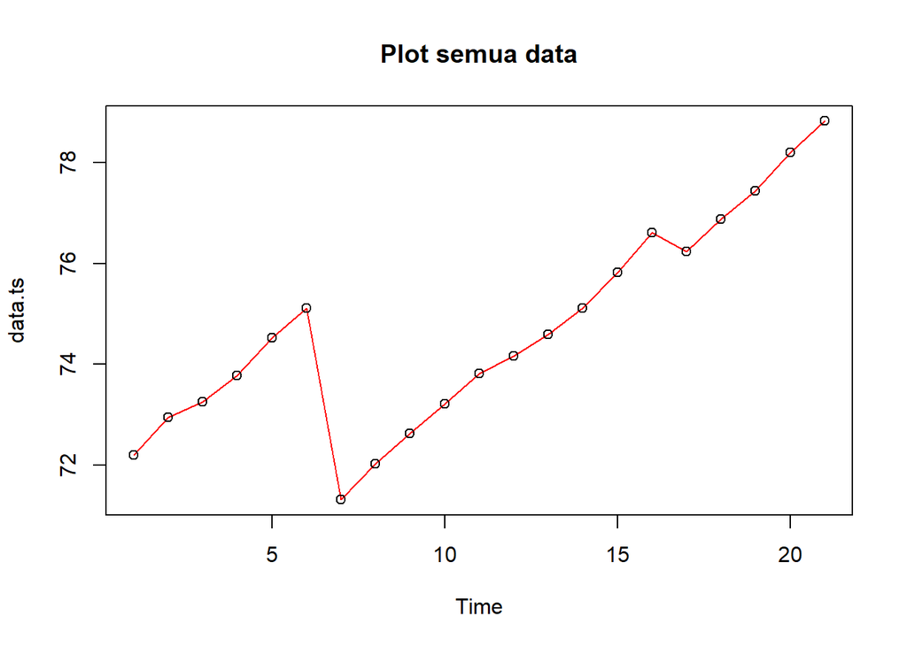

```r
#membagi training dan testing
training<-dtKaltim[1:17,2]
testing<-dtKaltim[18:21,2]

#data time series
training.ts<-ts(training, start=2004)
testing.ts<-ts(testing, start=2021)

#eksplorasi data
plot(data.ts, col="red",main="Plot semua data")
points(data.ts)
```

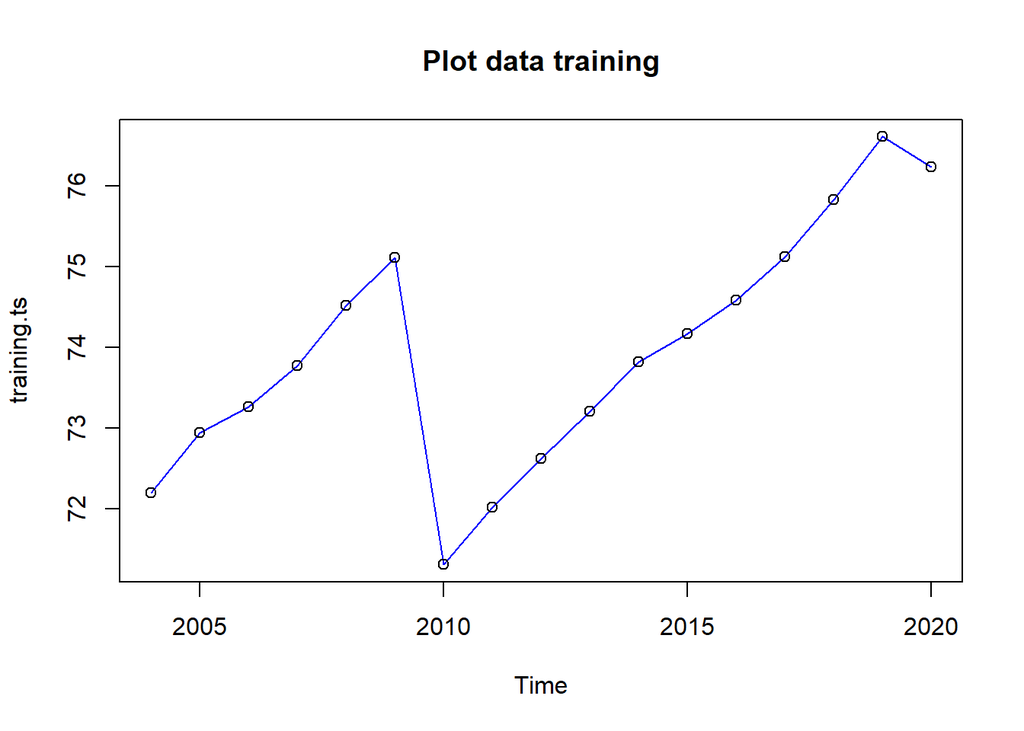

```r
plot(training.ts, col="blue",main="Plot data training")
points(training.ts)
```

# Lamda dan Gamma Optimum

```r
#Lamda dan gamma optimum
des.opt<- HoltWinters(training.ts, gamma = FALSE)
des.opt
```

```
## Holt-Winters exponential smoothing with trend and without seasonal component.
##
## Call:
## HoltWinters(x = training.ts, gamma = FALSE)
##
## Smoothing parameters:
##  alpha: 0.9509483
##  beta : 0.06917886
##  gamma: FALSE
##
## Coefficients:
##         [,1]
## a 76.2809263
## b  0.4258791
```

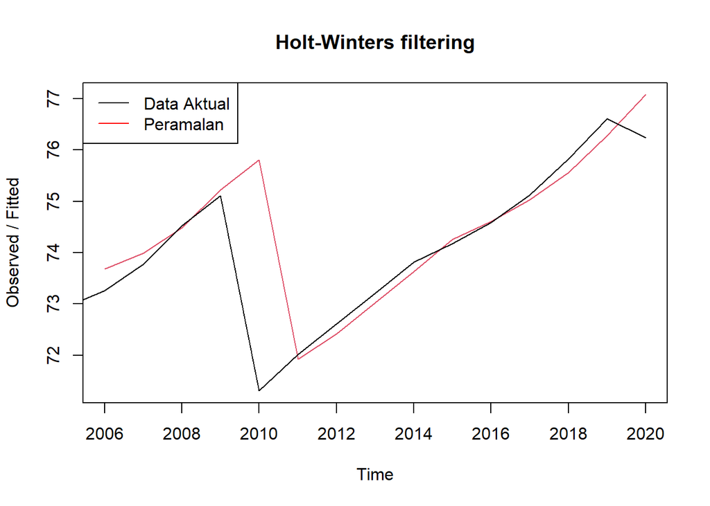

```r
plot(des.opt)
legend("topleft", c("Data Aktual", "Peramalan"), col = c("black", "red"),
       lty = c(1,1))
```

```r
#ramalan
ramalandesopt<- forecast(des.opt, h=5)
ramalandesopt
```

```
##      Point Forecast    Lo 80    Hi 80    Lo 95    Hi 95
## 2021       76.70681 75.17602 78.23759 74.36567 79.04794
## 2022       77.13268 74.94963 79.31573 73.79400 80.47137
## 2023       77.55856 74.81781 80.29931 73.36695 81.75018
## 2024       77.98444 74.72843 81.24046 73.00480 82.96408
## 2025       78.41032 74.66123 82.15941 72.67658 84.14406
```

Berdasarkan hasil peramalan dengan metode Double Exponential Smoothing (DES), diperoleh point forecast untuk periode 2021 hingga 2025. Nilai ramalan IPM Kalimantan Timur *diproyeksikan terus meningkat dari 76,71 pada tahun 2021 menjadi 78,41 pada tahun 2025.* Angka ini menunjukkan bahwa secara tren, IPM Kalimantan Timur diprediksi mengalami kenaikan yang relatif stabil setiap tahunnya.

Selain itu, hasil peramalan juga menyertakan interval prediksi 80% (Lo 80). Misalnya, pada tahun 2021 nilai IPM diperkirakan 76,71, namun dengan batas bawah sekitar 75,18. Semakin ke depan, rentang ketidakpastian cenderung melebar, misalnya pada tahun 2025 batas bawahnya ada di 74,66. Hal ini menggambarkan bahwa *semakin jauh ke masa depan, tingkat ketidakpastian peramalan semakin besar, meskipun tren utamanya tetap naik.*

# Akurasi Metode DES

```r
ssedes.train<-des.opt$SSE
msedes.train<-ssedes.train/length(training.ts)
sisaandes<-ramalandesopt$residuals
head(sisaandes)
```

```
## Time Series:
## Start = 2004
## End = 2009
## Frequency = 1
## [1]         NA         NA -0.4200000 -0.2229718  0.0413611 -0.1083939
```

```r
mapedes.train <- sum(abs(sisaandes[3:length(training.ts)]/training.ts[3:length(training.ts)])*100)/length(training.ts)

akurasides.opt <- matrix(c(ssedes.train,msedes.train,mapedes.train))
row.names(akurasides.opt)<- c("SSE", "MSE", "MAPE")
colnames(akurasides.opt) <- c("Akurasi lamda dan gamma optimum")
akurasides.opt
```

```
##      Akurasi lamda dan gamma optimum
## SSE                       21.4949642
## MSE                        1.2644097
## MAPE                       0.6148163
```

Nilai SSE = 21,49 dan MSE = 1,26 menunjukkan besarnya total error dan rata-rata error kuadrat. Sementara itu, *MAPE = 0,61% tergolong sangat kecil, yang berarti tingkat kesalahan relatif peramalan DES sangat rendah.* Dengan kata lain, model DES yang digunakan mampu menangkap tren IPM Kalimantan Timur dengan baik dan memberikan proyeksi yang dapat diandalkan.

```r
#Akurasi data testing
selisihdesopt<-ramalandesopt$mean-testing.ts
selisihdesopt
```

```
## Time Series:
## Start = 2021
## End = 2024
## Frequency = 1
## [1] -0.1731946 -0.3073155 -0.6414365 -0.8455574
```

```r
SSEtestingdesopt<-sum(selisihdesopt^2)
SSEtestingdesopt<-SSEtestingdesopt/length(testing.ts)
MAPEtestingdesopt<-sum(abs(selisihdesopt/testing.ts)*100)/length(testing.ts)

akurasiDesTesting <- matrix(c(SSEtestingdesopt,SSEtestingdesopt,MAPEtestingdesopt))
row.names(akurasiDesTesting)<- c("SSE", "MSE", "MAPE")
colnames(akurasiDesTesting) <- c("Akurasi lamda dan gamma optimum")
akurasiDesTesting
```

```
##      Akurasi lamda dan gamma optimum
## SSE                        0.3127118
## MSE                        0.3127118
## MAPE                       0.6287519
```

# Membandingkan Keakuratan Kedua Metode

```r
cbind(akurasi.dma, akurasides.opt)
```

```
##      Akurasi m = 3 Akurasi lamda dan gamma optimum
## SSE      32.906685                      21.4949642
## MSE       2.056668                       1.2644097
## MAPE      1.221280                       0.6148163
```

Berdasarkan hasil perhitungan, terlihat bahwa DES lebih unggul dibandingkan DMA dalam memodelkan data IPM Kalimantan Timur. Hal ini tercermin dari ukuran akurasi yang diperoleh. Pada metode DMA dengan 𝑚=3, nilai SSE = 32,91, MSE = 2,06, dan MAPE = 1,22%. Sementara itu, pada metode DES, nilai SSE turun menjadi 21,49, MSE menjadi 1,26, dan MAPE hanya 0,61%.

Perbandingan ini menunjukkan bahwa *DES menghasilkan error yang lebih kecil dibandingkan DMA.* Dengan kata lain, garis hasil pemulusan DES lebih mendekati nilai aktual data. Perbedaan paling mencolok dapat dilihat dari nilai MAPE: DES hanya setengah dari DMA, yang berarti tingkat kesalahan relatif DES hampir dua kali lebih baik.

Setelah melakukan peramalan, data yang telah dimasukkan kemudian dieksplorasi. Eksplorasi pertama yang dilakukan adalah dengan menggunakan *scatter plot*.

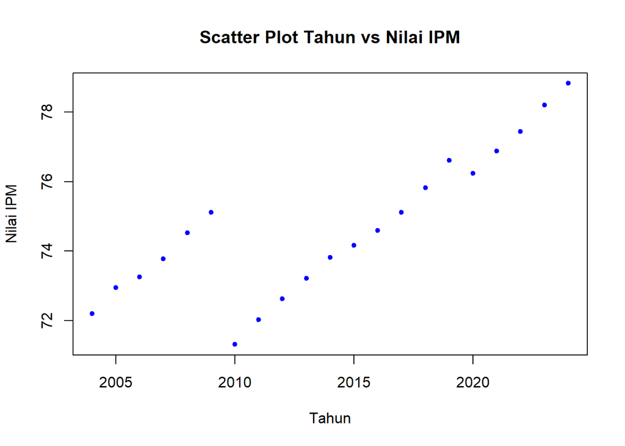

```r
#Eksplorasi Data
#Pembuatan Scatter Plot
plot(tahun,ipm, pch = 20, col = "blue",
     main = "Scatter Plot Tahun vs Nilai IPM",
     xlab = "Tahun",
     ylab = "Nilai IPM")
```

```r
#Menampilkan Nilai Korelasi
cor(tahun,ipm)
```

```
## [1] 0.8420066
```

Scatter plot Tahun vs Nilai IPM memperlihatkan adanya hubungan yang kuat dan positif antara perkembangan waktu dengan peningkatan IPM Kalimantan Timur. Titik-titik data menunjukkan pola yang cenderung naik dari tahun ke tahun, meskipun terdapat satu periode sekitar 2010 yang mengalami penurunan cukup signifikan. Setelah itu, nilai IPM kembali meningkat secara konsisten hingga tahun-tahun terakhir.

Hasil analisis kuantitatif memperkuat gambaran visual ini. *Nilai korelasi sebesar 0,842$ menunjukkan bahwa terdapat hubungan lnear positif yang sangat kuat antara tahun dan IPM.* Artinya, semakin bertambahnya tahun, IPM cenderung semakin meningkat dengan konsistensi yang tinggi.

# Model Regresi

```r
#Pembuatan Model Regresi
#model regresi
model<- lm(ipm~tahun, data = dtKaltim)
summary(model)
```

```
##
## Call:
## lm(formula = ipm ~ tahun, data = dtKaltim)
##
## Residuals:
##     Min      1Q  Median      3Q     Max
## -2.2521 -0.8139  0.1900  0.8353  1.8322
##
## Coefficients:
##              Estimate Std. Error t value Pr(>|t|)
## (Intercept) -497.9827    84.1760  -5.916 1.07e-05 ***
## tahun          0.2843     0.0418   6.803 1.70e-06 ***
## ---
## Signif. codes:  0 '***' 0.001 '**' 0.01 '*' 0.05 '.' 0.1 ' ' 1
##
## Residual standard error: 1.16 on 19 degrees of freedom
## Multiple R-squared:  0.709,  Adjusted R-squared:  0.6937
## F-statistic: 46.29 on 1 and 19 DF,  p-value: 1.701e-06
```

Model regresi yang diperoleh adalah

𝑦 ^ 𝑖 = − 497.9827 + 0.2843 𝑥 𝑡

Value sebesar 1.701e-06 yang lebih kecil dari taraf signifikansi 5% ( α=0.05). Hal ini berarti minimal terdapat satu variabel yang berpengaruh nyata terhadap model regresi.Hasil uji t parsial terhadap masing-masing parameter juga menunjukkan bahwa baik intersep (−497.9827) maupun koefisien regresi(0.2843) memiliki p-value < 0.05. Dengan demikian, keduanya signifikan pada taraf 5%, yang berarti variabel tahun berpengaruh nyata terhadap IPM.

Selain itu, nilai 𝑅2= 0.709 dan Adjusted 𝑅2 = 0.6937 mengindikasikan bahwa sekitar 70.9% variasi IPM dapat dijelaskan oleh variabel tahun, sedangkan sisanya (29.1%) dipengaruhi oleh faktor lain di luar model. Nilai residual standard error sebesar 1.16 menunjukkan penyimpangan prediksi model relatif kecil.

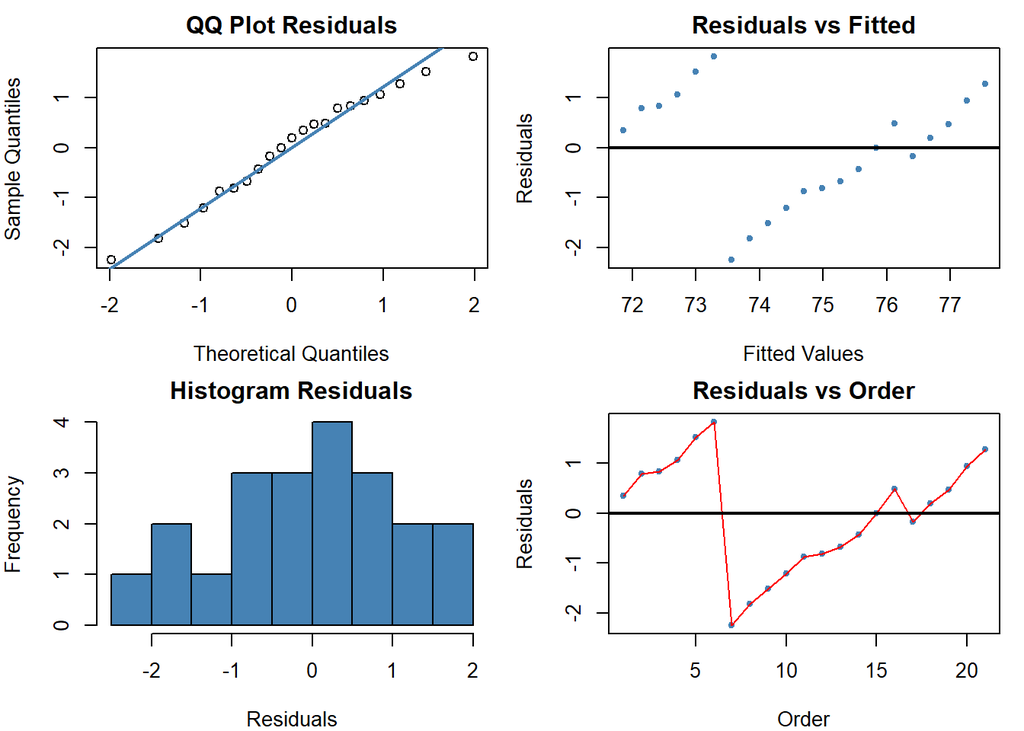

```r
sisaan <- as.numeric(residuals(model))
fitValue <- as.numeric(fitted(model))

# atur layout & margin
par(mfrow = c(2,2), mar = c(4,4,2,1))

# QQ Plot
qqnorm(sisaan, main = "QQ Plot Residuals")
qqline(sisaan, col = "steelblue", lwd = 2)

# Residual vs Fitted
plot(fitValue, sisaan, col = "steelblue", pch = 20,
     xlab = "Fitted Values", ylab = "Residuals", main = "Residuals vs Fitted")
abline(h = 0, lwd = 2)

# Histogram
hist(sisaan, col = "steelblue", main = "Histogram Residuals", xlab = "Residuals")

# Residual vs Order
plot(seq_along(sisaan), sisaan, col = "steelblue", pch = 20,
     xlab = "Order", ylab = "Residuals", main = "Residuals vs Order")
lines(seq_along(sisaan), sisaan, col = "red")
abline(h = 0, lwd = 2)
```

Hasil diagnostik model regresi menunjukkan bahwa asumsi normalitas residual relatif terpenuhi, *terlihat dari QQ Plot di mana sebagian besar titik mengikuti garis diagonal, serta histogram residual yang berbentuk simetris mendekati distribusi normal.* Hal ini mengindikasikan bahwa penyimpangan model terhadap asumsi normalitas tidak terlalu signifikan.

Namun, pada grafik Residuals vs Fitted tampak pola lengkung (berbentuk U), yang menunjukkan bahwa *residual tidak sepenuhnya menyebar acak di sekitar garis nol.* Kondisi ini mengindikasikan adanya potensi heteroskedastisitas atau pola non-linear yang belum ditangkap oleh model linier sederhana. Dengan demikian, meskipun model regresi tahun terhadap IPM dapat menjelaskan hubungan secara cukup baik, masih terdapat indikasi bahwa model dapat diperbaiki lebih lanjut.

```r
#Melihat Sisaan Menyebar Normal/Tidak
#H0: sisaan mengikuti sebaran normal
#H1: sisaan tidak mengikuti sebaran normal
shapiro.test(sisaan)
```

```
##
##  Shapiro-Wilk normality test
##
## data:  sisaan
## W = 0.97369, p-value = 0.8126
```

```r
ks.test(sisaan, "pnorm", mean=mean(sisaan), sd=sd(sisaan))
```

```
##
##  Exact one-sample Kolmogorov-Smirnov test
##
## data:  sisaan
## D = 0.095741, p-value = 0.9805
## alternative hypothesis: two-sided
```

Uji normalitas residual dengan Shapiro-Wilk menghasilkan nilai statistik 𝑊=0.97369 dengan p-value = 0.8126. Karena p-value lebih besar dari taraf signifikansi 5% (α=0.05), maka tidak ada alasan untuk menolak hipotesis nol. Artinya, residual berdistribusi normal.

Hasil ini diperkuat oleh uji Kolmogorov-Smirnov, di mana diperoleh 𝐷=0.095741 dengan p-value = 0.9805. Nilai p-value yang jauh lebih besar dari 0.05 juga menunjukkan bahwa residual mengikuti distribusi normal.

Dengan demikian, dapat disimpulkan bahwa asumsi normalitas residual pada model regresi terpenuhi dengan baik, sehingga model dapat digunakan untuk interpretasi lebih lanjut maupun peramalan.

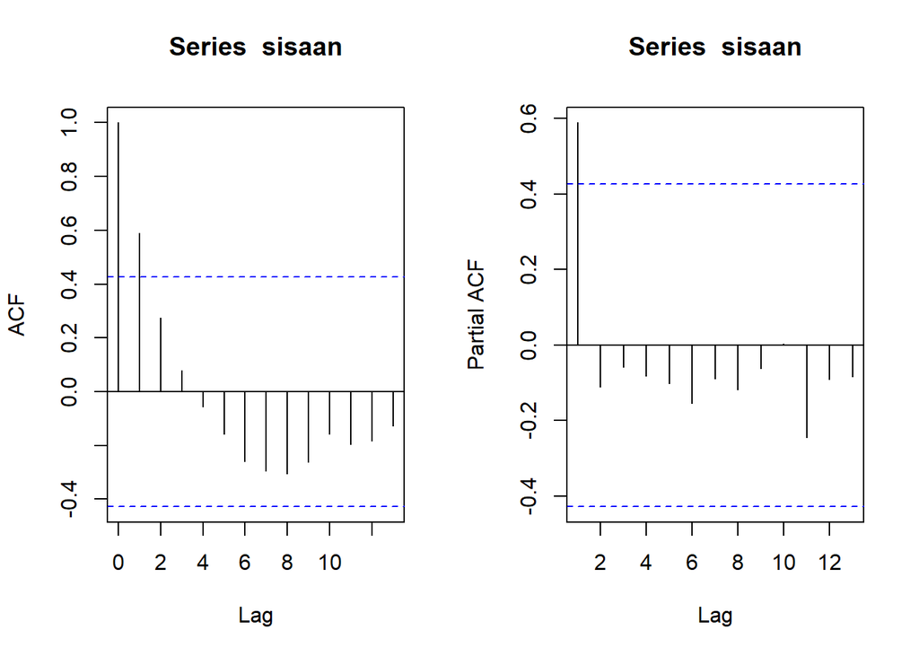

```r
#ACF dan PACF identifikasi autokorelasi
par(mfrow = c(1,2))
acf(sisaan)
pacf(sisaan)
```

```r
#Deteksi autokorelasi dengan uji-Durbin Watson
#H0: tidak ada autokorelasi
#H1: ada autokorelasi
dwtest(model)
```

```
##
##  Durbin-Watson test
##
## data:  model
## DW = 0.75201, p-value = 0.0001705
## alternative hypothesis: true autocorrelation is greater than 0
```

Berdasarkan hasil DW Test, didapatkan nilai $DW = 0.75201$ dan p-value = $0.0001705$. Berdasarkan tabel Durbin-Watson, diketahui bahwa nilai $DW$ jauh lebih kecil dibandingkan $DL$ maupun $DU$, sehingga hasil ini berada di daerah autokorelasi positif. Dengan p-value < 0.05, hipotesis nol ditolak dan terdapat cukup bukti untuk menyimpulkan adanya autokorelasi positif pada residual. Oleh karena itu, diperlukan penanganan terhadap autokorelasi. Penanganan yang dapat digunakan antara lain metode Cochrane-Orcutt dan Hildreth-Lu.

# Penanganan Autokorelasi

## Metode Cochrane-Orcutt

Penanganan metode Cochrane-Orcutt dapat dilakukan dengan bantuan packages Orcutt pada aplikasi `R` maupun secara manual. Berikut ini ditampilkan cara menggunakan bantuan `library` *packages* `Orcutt`.

```r
#Penanganan Autokorelasi Cochrane-Orcutt
modelCO<-cochrane.orcutt(model)
modelCO
```

```
## Cochrane-orcutt estimation for first order autocorrelation
##
## Call:
## lm(formula = ipm ~ tahun, data = dtKaltim)
##
##  number of interaction: 9
##  rho 0.641858
##
## Durbin-Watson statistic
## (original):    0.75201 , p-value: 1.705e-04
## (transformed): 1.88799 , p-value: 3.034e-01
##
##  coefficients:
## (Intercept)       tahun
## -601.922778    0.335934
```

Berdasarkan hasil estimasi dengan metode Cochrane-Orcutt, diperoleh nilai $\rho = 0.6419$, yang menunjukkan adanya korelasi positif pada residual orde pertama. Sebelum transformasi, uji Durbin-Watson menghasilkan $DW = 0.75201$ dengan p-value = $0.0001705$, sehingga terdapat cukup bukti adanya autokorelasi positif. Setelah dilakukan transformasi Cochrane-Orcutt, nilai $DW$ meningkat menjadi $1.88799$ dengan p-value = $0.3034$. Hal ini menunjukkan bahwa setelah koreksi, autokorelasi pada residual berhasil diatasi karena nilai DW sudah mendekati 2 dan tidak signifikan pada taraf 5%. Dengan demikian, model regresi setelah transformasi Cochrane-Orcutt dapat dianggap bebas autokorelasi.

Adapun persamaan regresi setelah koreksi menjadi:

𝐼 𝑃 𝑀 ^ = − 601.923 + 0.3359 ⋅ Tahun

yang berarti setiap kenaikan 1 tahun, nilai IPM di Kalimantan Timur diperkirakan meningkat sebesar 0.3359 poin.

```r
#Rho optimum
rho<- modelCO$rho
rho
```

```
## [1] 0.6418578
```

Selanjutnya akan dilakukan transformasi secara manual dengan syntax berikut ini.

```r
ipm
```

```
##  [1] 72.20 72.94 73.26 73.77 74.52 75.11 71.31 72.02 72.62 73.21 73.82 74.17
## [13] 74.59 75.12 75.83 76.61 76.24 76.88 77.44 78.20 78.83
```

```r
ipm[-1]
```

```
##  [1] 72.94 73.26 73.77 74.52 75.11 71.31 72.02 72.62 73.21 73.82 74.17 74.59
## [13] 75.12 75.83 76.61 76.24 76.88 77.44 78.20 78.83
```

```r
#Transformasi Manual
ipm.trans<- ipm[-1]-ipm[-12]*rho
tahun.trans<- tahun[-1]-tahun[-12]*rho
modelCOmanual<- lm(ipm.trans~tahun.trans)
summary(modelCOmanual)
```

```
##
## Call:
## lm(formula = ipm.trans ~ tahun.trans)
##
## Residuals:
##     Min      1Q  Median      3Q     Max
## -3.3692 -0.1923  0.0591  0.4155  0.9156
##
## Coefficients:
##              Estimate Std. Error t value Pr(>|t|)
## (Intercept) -186.9167    81.2447  -2.301   0.0336 *
## tahun.trans    0.2962     0.1126   2.631   0.0169 *
## ---
## Signif. codes:  0 '***' 0.001 '**' 0.01 '*' 0.05 '.' 0.1 ' ' 1
##
## Residual standard error: 0.9045 on 18 degrees of freedom
## Multiple R-squared:  0.2778, Adjusted R-squared:  0.2377
## F-statistic: 6.924 on 1 and 18 DF,  p-value: 0.01695
```

Hasil model transformasi bukan merupakan model sesungguhnya. Koefisien regresi masih perlu dicari kembali mengikuti $β_0^*=β_0+ρ ̂β_0$ dan $β_1^*=β_1$.

```r
#Mencari Penduga Koefisien Regresi setelah Transformasi ke Persamaan Awal
b0bintang <- modelCOmanual$coefficients[-2]
b0 <- b0bintang/(1-rho)
b1 <- modelCOmanual$coefficients[-1]
b0
```

```
## (Intercept)
##   -521.9065
```

```r
b1
```

```
## tahun.trans
##   0.2961606
```

## Metode Hildreth-Lu

Penanganan kedua adalah menggunakan metode Hildreth-Lu. Metode ini akan mencari nilai SSE terkecil dan dapat dicari secara manual maupun menggunakan packages. Jika menggunakan packages, gunakan `library` *packages* `HORM`.

```r
library(HoRM)

# ambil y dan x (satu prediktor saja)
y <- dtKaltim$ipm
x <- dtKaltim$tahun

# grid search rho 0–0.9
r <- seq(0, 0.9, by = 0.1)
tab <- data.frame(
  rho = r,
  SSE = sapply(r, function(rr) deviance(hildreth.lu(y, x, rr)))
)

tab            # tabel rho vs SSE
```

```
##    rho      SSE
## 1  0.0 25.41246
## 2  0.1 22.62569
## 3  0.2 20.30976
## 4  0.3 18.46469
## 5  0.4 17.09047
## 6  0.5 16.18710
## 7  0.6 15.75459
## 8  0.7 15.79293
## 9  0.8 16.30212
## 10 0.9 17.28216
```

```r
rho_hat <- tab$rho[which.min(tab$SSE)]   # rho terbaik
fit_hl  <- hildreth.lu(y, x, rho_hat)    # model final
summary(fit_hl)
```

```
##
## Call:
## lm(formula = y ~ x)
##
## Residuals:
##     Min      1Q  Median      3Q     Max
## -3.2936 -0.2993  0.1615  0.5014  0.9918
##
## Coefficients:
##              Estimate Std. Error t value Pr(>|t|)
## (Intercept) -234.7009    73.1390  -3.209  0.00487 **
## x              0.3284     0.0907   3.621  0.00195 **
## ---
## Signif. codes:  0 '***' 0.001 '**' 0.01 '*' 0.05 '.' 0.1 ' ' 1
##
## Residual standard error: 0.9356 on 18 degrees of freedom
## Multiple R-squared:  0.4214, Adjusted R-squared:  0.3893
## F-statistic: 13.11 on 1 and 18 DF,  p-value: 0.001954
```

Berdasarkan hasil estimasi dengan metode Hildreth-Lu, diperoleh persamaan regresi:

𝑦 ^ 𝑖 = − 234.7009 + 0.3284 𝑥 𝑡

Koefisien slope sebesar 0.3284 menunjukkan bahwa setiap kenaikan 1 unit pada variabel𝑥 diperkirakan akan meningkatkan nilai 𝑦sebesar 0.3284 poin. Hasil uji t menunjukkan bahwa parameter regresi signifikan pada taraf 5% (p-value = 0.00195), sehingga variabel 𝑥berpengaruh nyata terhadap y.

Nilai koefisien determinasi 𝑅2 =0.4214.(Adjusted 𝑅2=0.3893) menunjukkan bahwa sekitar 42.14% variasi 𝑦dapat dijelaskan oleh variabel 𝑥, sedangkan sisanya dipengaruhi oleh faktor lain di luar model. Dibandingkan dengan model awal (OLS) yang masih mengandung autokorelasi (DW = 0.75201), metode Hildreth-Lu memberikan model yang lebih reliabel karena telah memperhitungkan struktur autokorelasi dalam residual. Meskipun nilai 𝑅2lebih rendah dibanding OLS, hasil ini lebih valid karena asumsi klasik terpenuhi.

```r
#Penanganan Autokorelasi Hildreth lu
# Hildreth-Lu
hildreth.lu.func<- function(r, model){
  x <- model.matrix(model)[,-1]
  y <- model.response(model.frame(model))
  n <- length(y)
  t <- 2:n
  y <- y[t]-r*y[t-1]
  x <- x[t]-r*x[t-1]

  return(lm(y~x))
}

#Pencariab rho yang meminimumkan SSE
r <- c(seq(0.1,0.9, by= 0.1))
tab <- data.frame("rho" = r, "SSE" = sapply(r, function(i){deviance(hildreth.lu.func(i, model))}))
round(tab, 4)
```

```
##   rho     SSE
## 1 0.1 22.6257
## 2 0.2 20.3098
## 3 0.3 18.4647
## 4 0.4 17.0905
## 5 0.5 16.1871
## 6 0.6 15.7546
## 7 0.7 15.7929
## 8 0.8 16.3021
## 9 0.9 17.2822
```

```r
#Rho optimal di sekitar 0.4
rOpt <- seq(0.2,0.5, by= 0.001)
tabOpt <- data.frame("rho" = rOpt, "SSE" = sapply(rOpt, function(i){deviance(hildreth.lu.func(i, model))}))
head(tabOpt[order(tabOpt$SSE),])
```

```
##       rho      SSE
## 301 0.500 16.18710
## 300 0.499 16.19381
## 299 0.498 16.20056
## 298 0.497 16.20735
## 297 0.496 16.21420
## 296 0.495 16.22109
```

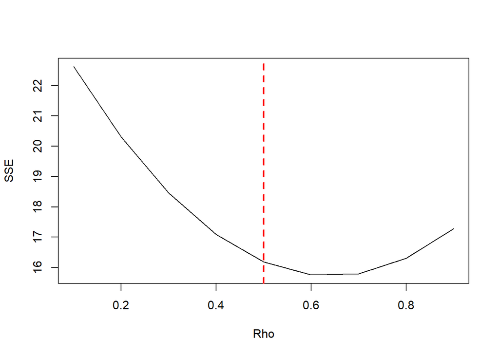

```r
#Grafik SSE optimum
par(mfrow = c(1,1))
plot(tab$SSE ~ tab$rho , type = "l", xlab = "Rho", ylab = "SSE")
abline(v = tabOpt[tabOpt$SSE==min(tabOpt$SSE),"rho"], lty = 2, col="red",lwd=2)
text(x=0.341, y=0.2397500, labels = "rho=0.341", cex = 0.8)
```

```r
#Model terbaik
modelHL <- hildreth.lu.func(0.500, model)
summary(modelHL)
```

```
##
## Call:
## lm(formula = y ~ x)
##
## Residuals:
##     Min      1Q  Median      3Q     Max
## -3.1130 -0.4080  0.1482  0.5840  1.1397
##
## Coefficients:
##               Estimate Std. Error t value Pr(>|t|)
## (Intercept) -280.40122   74.11773  -3.783 0.001361 **
## x              0.31553    0.07355   4.290 0.000441 ***
## ---
## Signif. codes:  0 '***' 0.001 '**' 0.01 '*' 0.05 '.' 0.1 ' ' 1
##
## Residual standard error: 0.9483 on 18 degrees of freedom
## Multiple R-squared:  0.5056, Adjusted R-squared:  0.4781
## F-statistic: 18.41 on 1 and 18 DF,  p-value: 0.0004406
```

```r
#Transformasi Balik
cat("y = ", coef(modelHL)[1]/(1-0.500), "+", coef(modelHL)[2],"x", sep = "")
```

```
## y = -560.8024+0.3155338x
```

Setelah dilakukan tranformasi balik, didapatkan model dengan metode Hildreth-Lu sebagai berikut.
$$y_i=-560.8024+0.3155338x_t$$

```r
#Deteksi autokorelasi
dwtest(modelHL)
```

```
##
##  Durbin-Watson test
##
## data:  modelHL
## DW = 1.6033, p-value = 0.1194
## alternative hypothesis: true autocorrelation is greater than 0
```

Berdasarkan hasil uji Durbin-Watson, diperoleh nilai 𝐷𝑊= 1.6033. Nilai ini berada dalam selang daerah tidak ada autokorelasi, yaitu 𝐷𝑈<𝐷𝑊<4−𝐷𝑈 atau 1.331<1.6033<2.669. Kondisi tersebut juga didukung oleh hasil p-value sebesar 0.1194, di mana p-value lebih besar daripada taraf signifikansi α=5%.Artinya, hipotesis nol yang menyatakan tidak ada autokorelasi tidak ditolak. Dengan demikian, belum terdapat cukup bukti untuk menyatakan adanya autokorelasi dalam model regresi nilai IPM yang diestimasi menggunakan metode Hildreth-Lu pada taraf nyata 5%.

Model hasil Hildreth-Lu ini dapat dianggap telah terbebas dari permasalahan autokorelasi, sehingga persamaan regresi hasil transformasi balik layak digunakan sebagai persamaan akhir dalam memodelkan hubungan antara tahun dengan nilai IPM di Kalimantan Timur.

Terakhir, akan dibandingkan nilai SSE dari ketiga metode (metode awal, metode Cochrane-Orcutt, dan Hildreth-Lu).

```r
#Perbandingan
sseModelawal <- anova(model)$`Sum Sq`[-1]
sseModelCO <- anova(modelCOmanual)$`Sum Sq`[-1]
sseModelHL <- anova(modelHL)$`Sum Sq`[-1]
mseModelawal <- sseModelawal/length(ipm)
mseModelCO <- sseModelCO/length(ipm)
mseModelHL <- sseModelHL/length(ipm)
akurasi <- matrix(c(sseModelawal,sseModelCO,sseModelHL,
                    mseModelawal,mseModelCO,mseModelHL),nrow=2,ncol=3,byrow = T)
colnames(akurasi) <- c("Model Awal", "Model Cochrane-Orcutt", "Model Hildreth-Lu")
row.names(akurasi) <- c("SSE","MSE")
akurasi
```

```
##     Model Awal Model Cochrane-Orcutt Model Hildreth-Lu
## SSE  25.556321            14.7257105        16.1871039
## MSE   1.216968             0.7012243         0.7708145
```

Berdasarkan hasil perbandingan tiga model regresi yang digunakan, terlihat adanya perbedaan kinerja yang cukup jelas. Model awal menghasilkan nilai Sum of Squared Errors (SSE) sebesar 25.5563 dan Mean Squared Error (MSE) sebesar 1.2170. Nilai ini relatif lebih besar dibandingkan dengan dua model koreksi autokorelasi yang digunakan.

Setelah dilakukan koreksi menggunakan metode Cochrane-Orcutt, diperoleh penurunan yang signifikan pada nilai kesalahan, dengan SSE sebesar 14.7257 dan MSE sebesar 0.7012. Hasil ini menunjukkan bahwa model Cochrane-Orcutt mampu memperbaiki permasalahan autokorelasi sekaligus meningkatkan ketepatan model.

Sementara itu, metode Hildreth-Lu juga menunjukkan hasil perbaikan dengan SSE sebesar 16.1871 dan MSE sebesar 0.7708. Nilai ini lebih baik daripada model awal, meskipun masih sedikit lebih tinggi dibandingkan model Cochrane-Orcutt.

Autokorelasi dapat dideteksi secara eksploratif melalui plot sisaan, ACF, dan PACF, serta dengan uji formal Durbin-Watson. Hasil pengujian menunjukkan adanya autokorelasi pada model awal. Namun, setelah dilakukan penanganan dengan metode Cochrane-Orcutt dan Hildreth-Lu, diperoleh model yang lebih baik.

Kedua metode tersebut mampu menurunkan nilai SSE dan MSE dibandingkan model awal, sehingga keduanya layak digunakan. Akan tetapi, metode Cochrane-Orcutt terbukti lebih optimal, karena memberikan nilai SSE dan MSE yang lebih kecil daripada metode Hildreth-Lu. Dengan demikian, model Cochrane-Orcutt dapat dianggap sebagai model terbaik dalam menangani autokorelasi pada data IPM Kalimantan Timur.